# Introduction to R, part D

cs4821-s17

IntroA | IntroB | IntroC | IntroD

The following examples go through using several of R’s basic functions.

Load the *mpg* data set.

```r
library(ggplot2)
data(mpg)
```

## Sorting

Sort values using the `sort` function

```r
x <- mpg$hwy[1:10]
x
```

```
##  [1] 29 29 31 30 26 26 27 26 25 28
```

```r
sort(x)
```

```
##  [1] 25 26 26 26 27 28 29 29 30 31
```

The ordering of a vector may also be found

```r
y <- 1:10
o <- order(x)
x[o]
```

```
##  [1] 25 26 26 26 27 28 29 29 30 31
```

```r
y[o]
```

```
##  [1]  9  5  6  8  7 10  1  2  4  3
```

## Functions

A new function can be defined by assigning the function to the object name. Let’s create a function to calculate standard error.

$$\text{standard error} = \sqrt{\frac{s^2}{n}}$$

```r
se <- function(x) {
  v <- var(x)
  n <- length(x)
  return(sqrt(v/n))
}
se(c(45, 2, 5, 8, 65, 4))
```

```
## [1] 10.93237
```

A function may be used to calculate basis statistics on a vector:

```r
basic.stats <- function(x, more=F) {
  stats <- list()

  clean.x <- x[!is.na(x)]

  stats$n <- length(x)
  stats$nNAs <- stats$n - length(clean.x)

  stats$mean <- mean(clean.x)
  stats$std <- sd(clean.x)
  stats$med <- median(clean.x)
  if (more) {
    stats$skew <- sum(((clean.x-stats$mean)/stats$std)^3) /
      length(clean.x)
  }
  unlist(stats)
}
basic.stats(c(40, 2, 3, 5, 10, 55, 8, -400))
```

```
##        n     nNAs     mean      std      med
##   8.0000   0.0000 -34.6250 148.9179   6.5000
```

```r
basic.stats(c(40, 2, 3, 5, 10, 55, 8, -400), more=T)
```

```
##          n       nNAs       mean        std        med       skew
##   8.000000   0.000000 -34.625000 148.917942   6.500000  -1.790724
```

This example also introduced some program control namely `if` functions

## Program Control

A simple example using *for* loops

```r
for (i in 1:10) {
  print(i^2)
}
```

```
## [1] 1
## [1] 4
## [1] 9
## [1] 16
## [1] 25
## [1] 36
## [1] 49
## [1] 64
## [1] 81
## [1] 100
```

```r
for (i in c("red", "green", "blue")) {
  print(i)
}
```

```
## [1] "red"
## [1] "green"
## [1] "blue"
```

Note, R like vector has many functions that work on vectors. Therefore, vectorized version of calculations and operations are often preferred over loops to ensure efficient code.

```r
i <- 0
while (i < 10) {
  print(i)
  i <- i + 1
}
```

```
## [1] 0
## [1] 1
## [1] 2
## [1] 3
## [1] 4
## [1] 5
## [1] 6
## [1] 7
## [1] 8
## [1] 9
```

## Plotting and Saving Results

Let’s look at a basic scatter plot

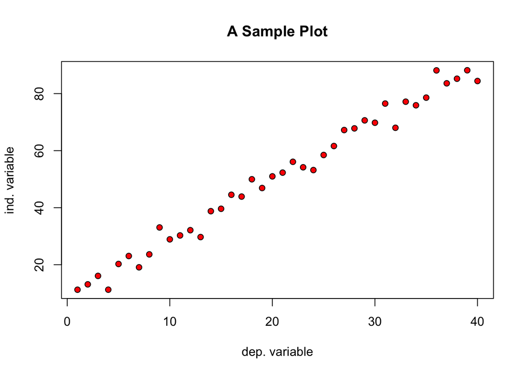

```r
x = c(1:40)
y = x*2 + 10 + rnorm(40)*3
plot(x, y, pch=21, bg="red",
     main="A Sample Plot", xlab="dep. variable", ylab="ind. variable")
```

Inspired by and following examples of J. Taylor using Sphinx, R introduction's from D. Cook and L. Turgo, and C. Grandrud's Reproducible Research.

cs4821 - Data Mining - Spring 2017  
updated: January 10, 2017